# R Notebook

## Short description of our project

Team: Sofiia Popeniuk, Sofiia Sampara, Ostap Pavlyshyn

Link to dataset: https://www.kaggle.com/datasets/patricklford/earthquakes-historical-data-and-live-data?select=earthquake_1995-2023.csv

Key Variables:

```r
library(readr)
data <- read_csv("dataset/earthquake_1995-2023.csv")
head(data)
```

| title | magnitude | date_time | cdi | mmi | alert | tsunami | sig | net | nst | dmin | gap | magType | depth | latitude | longitude | location | continent | country |
| --- | --- | --- | --- | --- | --- | --- | --- | --- | --- | --- | --- | --- | --- | --- | --- | --- | --- | --- |
| M 6.5 - 42 km W of Sola, Vanuatu | 6.5 | 16-08-2023 12:47 | 7 | 4 | green | 0 | 657 | us | 114 | 7.177000 | 25.0 | mww | 192.955 | -13.8814 | 167.1580 | Sola, Vanuatu | NA | Vanuatu |
| M 6.5 - 43 km S of Intipucá, El Salvador | 6.5 | 19-07-2023 00:22 | 8 | 6 | yellow | 0 | 775 | us | 92 | 0.679000 | 40.0 | mww | 69.727 | 12.8140 | -88.1265 | Intipucá, El Salvador | NA | El Salvador |
| M 6.6 - 25 km ESE of Loncopué, Argentina | 6.6 | 17-07-2023 03:05 | 7 | 5 | green | 0 | 899 | us | 70 | 1.634000 | 28.0 | mww | 171.371 | -38.1911 | -70.3731 | Loncopué, Argentina | South America | Argentina |
| M 7.2 - 98 km S of Sand Point, Alaska | 7.2 | 16-07-2023 06:48 | 6 | 6 | green | 1 | 860 | us | 173 | 0.907000 | 36.0 | mww | 32.571 | 54.3844 | -160.6990 | Sand Point, Alaska | NA | United States |
| M 7.3 - Alaska Peninsula | 7.3 | 16-07-2023 06:48 | 0 | 5 | NA | 1 | 820 | at | 79 | 0.879451 | 172.8 | Mi | 21.000 | 54.4900 | -160.7960 | Alaska Peninsula | NA | United States |
| M 6.6 - 277 km NNE of Codrington, Antigua and Barbuda | 6.6 | 10-07-2023 20:28 | 5 | 4 | green | 1 | 802 | us | 95 | 2.454000 | 37.0 | mww | 10.000 | 20.0196 | -61.0955 | Codrington, Antigua and Barbuda | NA | NA |

Short description what every variable mean: • Title is a name given to the earthquake for identification.

• Magnitude measures earthquake size, reflecting potential destruction.

• Date and Time records the timestamp of each earthquake.

• CDI is a maximum reported intensity of the earthquake as recorded by the community.

• MMI is a maximum estimated instrumental intensity, indicating the earthquake’s observed effects.

• Alert is a classification of the event’s alert level, with values such as “green,” “yellow,” “orange,” and “red,” indicating severity.

• Tsunami indicates whether the event occurred in an oceanic region (“1”) or not (“0”), relevant for tsunami risk.

• Significance (sig) a numerical value describing the event’s significance, factoring in magnitude, MMI, and reported impacts.

• Net is the data contributor’s ID, signifying the network considered the preferred source of information.

• NST (Number of Seismic Stations) is a total number of seismic stations used to calculate the earthquake’s location.

• Dmin is a horizontal distance from the epicenter to the nearest seismic station, influencing location accuracy.

• Gap is a largest azimuthal gap between adjacent stations, affecting the reliability of the calculated earthquake position.

• MagType is the algorithm or method used to determine the preferred magnitude.

• Depth below the Earth’s surface where the earthquake begins to rupture, influencing surface damage.

• Latitude/Longitude is a geographical coordinates for locating the earthquake on Earth’s surface and analyzing regional trends.

• Location within the country affected by the earthquake.

• Continent here the affected country is located.

• Country that experienced the earthquake.

## The descriptive analysis of the dataset

1. Reading the data from the file.

```r
head(data)
```

| title | magnitude | date_time | cdi | mmi | alert | tsunami | sig | net | nst | dmin | gap | magType | depth | latitude | longitude | location | continent | country |
| --- | --- | --- | --- | --- | --- | --- | --- | --- | --- | --- | --- | --- | --- | --- | --- | --- | --- | --- |
| M 6.5 - 42 km W of Sola, Vanuatu | 6.5 | 16-08-2023 12:47 | 7 | 4 | green | 0 | 657 | us | 114 | 7.177000 | 25.0 | mww | 192.955 | -13.8814 | 167.1580 | Sola, Vanuatu | NA | Vanuatu |
| M 6.5 - 43 km S of Intipucá, El Salvador | 6.5 | 19-07-2023 00:22 | 8 | 6 | yellow | 0 | 775 | us | 92 | 0.679000 | 40.0 | mww | 69.727 | 12.8140 | -88.1265 | Intipucá, El Salvador | NA | El Salvador |
| M 6.6 - 25 km ESE of Loncopué, Argentina | 6.6 | 17-07-2023 03:05 | 7 | 5 | green | 0 | 899 | us | 70 | 1.634000 | 28.0 | mww | 171.371 | -38.1911 | -70.3731 | Loncopué, Argentina | South America | Argentina |
| M 7.2 - 98 km S of Sand Point, Alaska | 7.2 | 16-07-2023 06:48 | 6 | 6 | green | 1 | 860 | us | 173 | 0.907000 | 36.0 | mww | 32.571 | 54.3844 | -160.6990 | Sand Point, Alaska | NA | United States |
| M 7.3 - Alaska Peninsula | 7.3 | 16-07-2023 06:48 | 0 | 5 | NA | 1 | 820 | at | 79 | 0.879451 | 172.8 | Mi | 21.000 | 54.4900 | -160.7960 | Alaska Peninsula | NA | United States |
| M 6.6 - 277 km NNE of Codrington, Antigua and Barbuda | 6.6 | 10-07-2023 20:28 | 5 | 4 | green | 1 | 802 | us | 95 | 2.454000 | 37.0 | mww | 10.000 | 20.0196 | -61.0955 | Codrington, Antigua and Barbuda | NA | NA |

```r
summary(data)
```

```
##     title             magnitude     date_time              cdi
##  Length:1000        Min.   :6.50   Length:1000        Min.   :0.000
##  Class :character   1st Qu.:6.60   Class :character   1st Qu.:0.000
##  Mode  :character   Median :6.80   Mode  :character   Median :4.000
##                     Mean   :6.94                      Mean   :3.605
##                     3rd Qu.:7.10                      3rd Qu.:7.000
##                     Max.   :9.10                      Max.   :9.000
##       mmi            alert              tsunami           sig
##  Min.   : 1.000   Length:1000        Min.   :0.000   Min.   : 650.0
##  1st Qu.: 5.000   Class :character   1st Qu.:0.000   1st Qu.: 691.0
##  Median : 6.000   Mode  :character   Median :0.000   Median : 744.0
##  Mean   : 6.027                      Mean   :0.325   Mean   : 847.9
##  3rd Qu.: 7.000                      3rd Qu.:1.000   3rd Qu.: 874.2
##  Max.   :10.000                      Max.   :1.000   Max.   :2910.0
##      net                 nst             dmin             gap
##  Length:1000        Min.   :  0.0   Min.   : 0.000   Min.   :  0.00
##  Class :character   1st Qu.:  0.0   1st Qu.: 0.000   1st Qu.:  0.00
##  Mode  :character   Median :  0.0   Median : 0.000   Median : 18.00
##                     Mean   :193.9   Mean   : 1.125   Mean   : 20.93
##                     3rd Qu.:403.0   3rd Qu.: 1.549   3rd Qu.: 27.00
##                     Max.   :934.0   Max.   :17.654   Max.   :239.00
##    magType              depth           latitude         longitude
##  Length:1000        Min.   :  2.70   Min.   :-61.848   Min.   :-179.97
##  Class :character   1st Qu.: 16.00   1st Qu.:-13.518   1st Qu.: -71.69
##  Mode  :character   Median : 29.00   Median : -2.443   Median : 107.79
##                     Mean   : 74.61   Mean   :  4.316   Mean   :  51.49
##                     3rd Qu.: 55.00   3rd Qu.: 25.167   3rd Qu.: 148.36
##                     Max.   :670.81   Max.   : 71.631   Max.   : 179.66
##    location          continent           country
##  Length:1000        Length:1000        Length:1000
##  Class :character   Class :character   Class :character
##  Mode  :character   Mode  :character   Mode  :character
##
##
##
```

2. Testing common distributions

```r
library(nortest)
analyze_variable <- function(var_name, data) {
  var_data <- data[[var_name]]
  var_data <- unique(var_data)
  if (is.character(var_data) || is.factor(var_data) || length(unique(var_data)) < 10) {
    cat("Categorical Variable:", var_name, "\n")
    counts <- table(var_data, useNA = "ifany")
    cat("\n")
  } else {
    cat("Numerical Variable:", var_name, "\n")
    var_data <- na.omit(as.numeric(var_data))
    if (length(var_data) > 1) {
      is_discrete <- all(var_data == floor(var_data))

      normal_test <- ad.test(var_data)$p.value
      exp_test <- ks.test(var_data, "pexp", rate = 1 / mean(var_data))$p.value
      unif_test <- ks.test(var_data, "punif", min = min(var_data), max = max(var_data))$p.value
      chi_square_test <- ks.test(var_data, "pchisq", df = mean(var_data))$p.value

      closest_dist <- ifelse(normal_test > 0.05, "Normal",
                             ifelse(exp_test > 0.05, "Exponential",
                                    ifelse(unif_test > 0.05, "Uniform",
                                                  ifelse(chi_square_test > 0.05, "Chi-Square", "Unknown"))))

      cat("  Is Discrete:", is_discrete, "\n")
      cat("  Normality test p-value:", normal_test, "\n")
      cat("  Exponential test p-value:", exp_test, "\n")
      cat("  Uniform test p-value:", unif_test, "\n")
      cat("  Chi-Square test p-value:", chi_square_test, "\n")
      cat("  Closest distribution:", closest_dist, "\n\n")
    } else {
      cat("  Insufficient data for analysis.\n\n")
    }
  }
}

for (var in colnames(data)) {
  analyze_variable(var, data)
}
```

```
## Categorical Variable: title
##
## Numerical Variable: magnitude
##   Is Discrete: FALSE
##   Normality test p-value: 0.8931148
##   Exponential test p-value: 2.96501e-08
##   Uniform test p-value: 0.582236
##   Chi-Square test p-value: 5.336068e-05
##   Closest distribution: Normal
##
## Categorical Variable: date_time
##
## Numerical Variable: cdi
##   Is Discrete: TRUE
##   Normality test p-value: 0.9566579
##   Exponential test p-value: 0.8049689
##   Uniform test p-value: 0.9996371
##   Chi-Square test p-value: 0.9558713
##   Closest distribution: Normal
##
## Numerical Variable: mmi
##   Is Discrete: TRUE
##   Normality test p-value: 0.9566579
##   Exponential test p-value: 0.6402654
##   Uniform test p-value: 0.9996371
##   Chi-Square test p-value: 0.9805806
##   Closest distribution: Normal
##
## Categorical Variable: alert
##
## Categorical Variable: tsunami
##
## Numerical Variable: sig
##   Is Discrete: TRUE
##   Normality test p-value: 3.7e-24
##   Exponential test p-value: 2.680821e-68
##   Uniform test p-value: 8.605445e-92
##   Chi-Square test p-value: 7.860526e-90
##   Closest distribution: Unknown
##
```

[output cut: 42 more lines]

```
##   Closest distribution: Unknown
##
## Numerical Variable: longitude
##   Is Discrete: FALSE
##   Normality test p-value: 3.7e-24
##   Exponential test p-value: 1.07585e-150
##   Uniform test p-value: 2.768044e-100
##   Chi-Square test p-value: 1.659878e-302
##   Closest distribution: Unknown
##
## Categorical Variable: location
##
## Categorical Variable: continent
##
## Categorical Variable: country
```

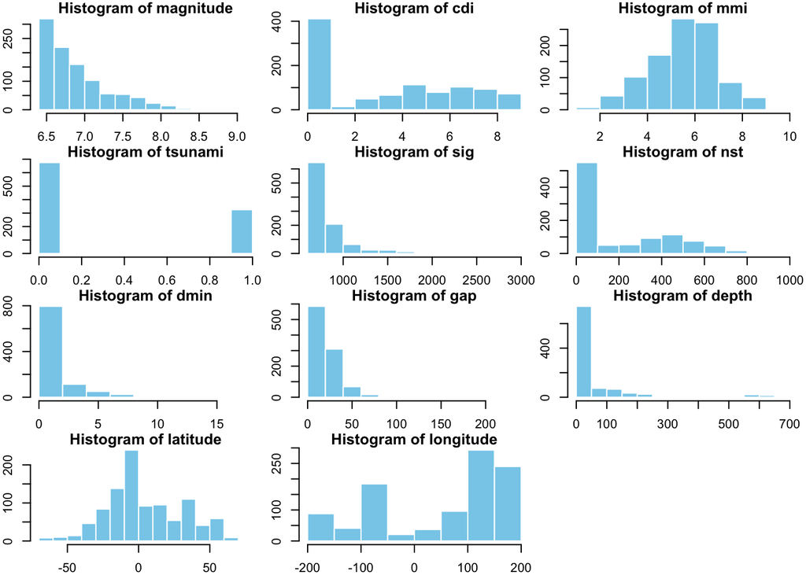

```r
numeric_vars <- sapply(data, is.numeric)
numeric_data <- data[, numeric_vars]

num_vars <- sum(numeric_vars)
rows <- ceiling(sqrt(num_vars))
cols <- ceiling(num_vars / rows)

par(mfrow = c(rows, cols), mar = c(2, 2, 1, 0.5))

for (var_name in colnames(numeric_data)) {
  hist(numeric_data[[var_name]],
       main = paste("Histogram of", var_name),
       xlab = var_name,
       col = "skyblue",
       border = "white")
}

par(mfrow = c(1, 1))
```

3. How many values of the data are NA?

```r
colSums(is.na(data))
```

```
##     title magnitude date_time       cdi       mmi     alert   tsunami       sig
##         0         0         0         0         0       551         0         0
##       net       nst      dmin       gap   magType     depth  latitude longitude
##         0         0         0         0         0         0         0         0
##  location continent   country
##         6       716       995
```

A lot of data in the continent and country column are not defined (what to do with this? maybe, we should not take into account this data)

4. Prepare data (make date-time column in proper format)

```r
library(lubridate)
data$date_time <- dmy_hm(data$date_time)
```

5. Summary on some data

```r
library(ggplot2)
print("The summary of the magnitude of the earthquakes")
```

```
## [1] "The summary of the magnitude of the earthquakes"
```

```r
summary(data$magnitude)
```

```
##    Min. 1st Qu.  Median    Mean 3rd Qu.    Max.
##    6.50    6.60    6.80    6.94    7.10    9.10
```

```r
print("The summary of the maximum reported intensity for the event")
```

```
## [1] "The summary of the maximum reported intensity for the event"
```

```r
summary(data$cdi)
```

```
##    Min. 1st Qu.  Median    Mean 3rd Qu.    Max.
##   0.000   0.000   4.000   3.605   7.000   9.000
```

```r
print("The summary of the maximum estimated instrumental intensity for the event")
```

```
## [1] "The summary of the maximum estimated instrumental intensity for the event"
```

```r
summary(data$mmi)
```

```
##    Min. 1st Qu.  Median    Mean 3rd Qu.    Max.
##   1.000   5.000   6.000   6.027   7.000  10.000
```

6. Interesting distribution

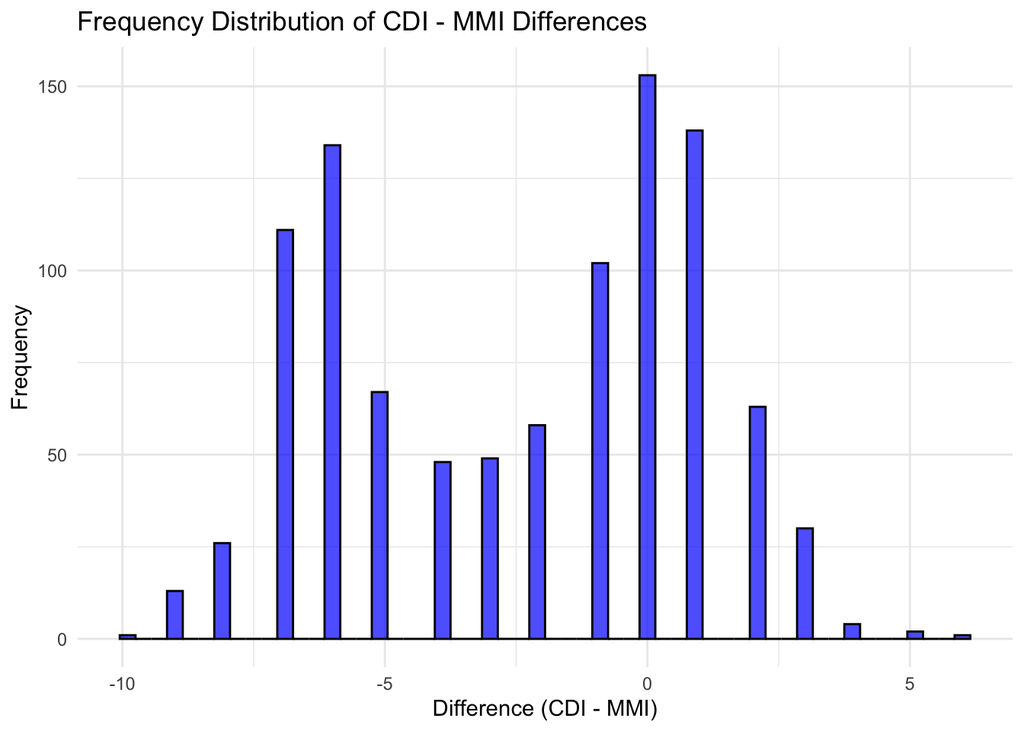

```r
library(ggplot2)

cdi_mmi_diff <- data$cdi - data$mmi

ggplot(data.frame(cdi_mmi_diff), aes(x = cdi_mmi_diff)) +
  geom_histogram(binwidth = 0.3, fill = "blue", color = "black", alpha = 0.7) +
  labs(
    title = "Frequency Distribution of CDI - MMI Differences",
    x = "Difference (CDI - MMI)",
    y = "Frequency"
  ) +
  theme_minimal()
```

```r
table(data$alert)
```

```
##
##  green orange    red yellow
##    353     24     13     59
```

```r
table(data$magType)
```

```
##
##  mb  md  Mi  ml  ms  mw mwb mwc mww
##   4   2   5   1   3  51 100 332 502
```

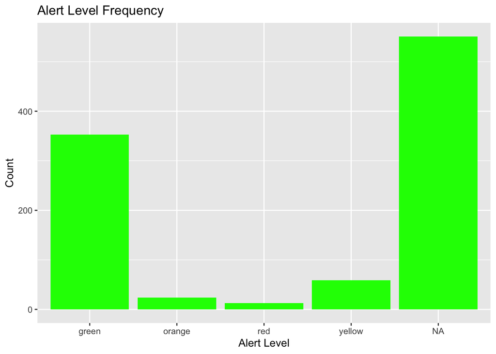

```r
ggplot(data, aes(x = alert)) + geom_bar(fill = "green") +
    labs(title = "Alert Level Frequency", x = "Alert Level", y = "Count")
```

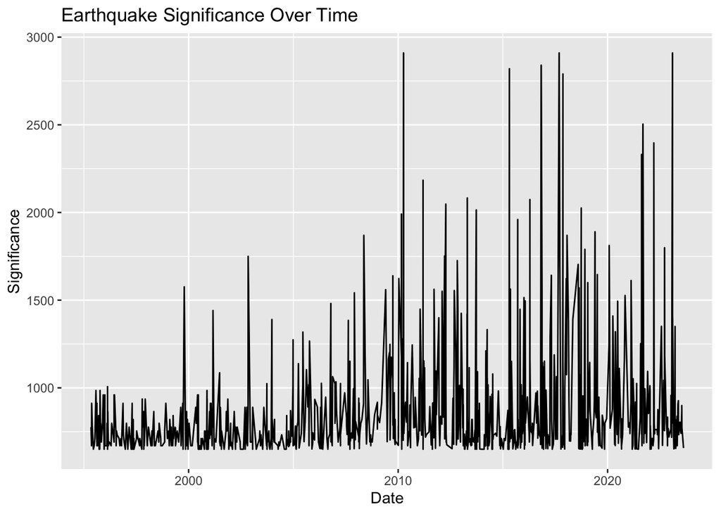

```r
ggplot(data, aes(x = date_time, y = sig)) + geom_line() +
    labs(title = "Earthquake Significance Over Time", x = "Date", y = "Significance")
```

# Hypothesis and Descriptions

## Hypothesis: Geographic Patterns of Magnitude

Hypothesis:  
Earthquakes in specific continents or regions (e.g., along tectonic plate boundaries) tend to have higher magnitudes than those in other regions.

Description:  
This hypothesis examines the geographic distribution of earthquake magnitudes, particularly focusing on whether regions associated with tectonic plate boundaries experience stronger earthquakes. By analyzing the “magnitude” variable in conjunction with “country`, this hypothesis aims to identify spatial trends in seismic activity. This can provide insights into the global distribution of tectonic forces and their impact on earthquake magnitudes.

Statistical Hypotheses:  
- $H_0$: There is no association between earthquake magnitude category and continent. - $H_1$: There is an association between earthquake magnitude category and continent.

The provided R code output NA values in the dataset before and after data filling for specific columns. The code of preproccessing is in file fillCountry.py.

```r
library(knitr)
# Calculate NA counts for 'country' and 'magnitude' columns
na_country <- sum(is.na(data[['country']]))
na_magnitude <- sum(is.na(data[['magnitude']]))
na_continent <- sum(is.na(data[['continent']]))

na_summary <- data.frame(
  Column = c("country", "magnitude", "continent"),
  NA_Count = c(na_country, na_magnitude, na_continent)
)

# Display the summary table
kable(na_summary, caption = "Summary of missing values before filling data")
```

Summary of missing values before filling data

| Column | NA_Count |
| --- | --- |
| country | 995 |
| magnitude | 0 |
| continent | 716 |

```r
# Read the dataset with filled countries
data_country <- read_csv("dataset/earthquake_1995-2023-country.csv", show_col_types = FALSE)
na_country <- sum(is.na(data_country[['country']]))
na_magnitude <- sum(is.na(data_country[['magnitude']]))
na_continent <- sum(is.na(data_country[['continent']]))

na_summary_country <- data.frame(
  Column = c("country", "magnitude", "continent"),
  NA_Count = c(na_country, na_magnitude, na_continent)
)
kable(na_summary_country, caption = "Summary of missing values after filling data")
```

Summary of missing values after filling data

| Column | NA_Count |
| --- | --- |
| country | 27 |
| magnitude | 0 |
| continent | 89 |

The code below creates a visual representation of earthquake locations on a world map.

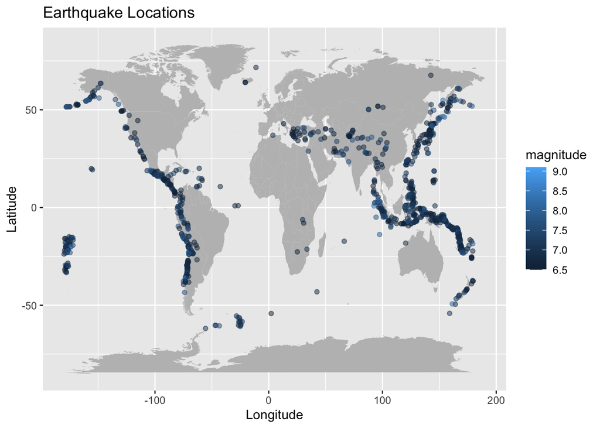

```r
world_map <- map_data("world")
ggplot() +
    geom_polygon(data = world_map, aes(x = long, y = lat, group = group), fill = "gray") +
    geom_point(data = data_country, aes(x = longitude, y = latitude, color = magnitude), alpha = 0.5) +
    labs(title = "Earthquake Locations", x = "Longitude", y = "Latitude")
```

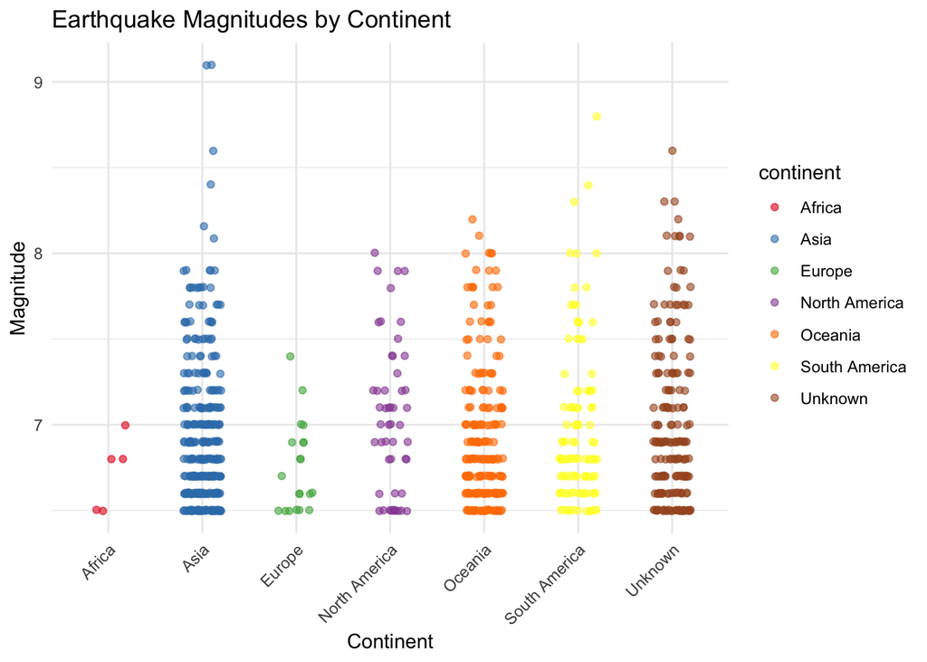

```r
library(ggplot2)
#combining the same continents with different names
data_country$continent <- gsub("AF", "Africa", data_country$continent)
data_country$continent <- gsub("AS", "Asia", data_country$continent)
data_country$continent <- gsub("EU", "Europe", data_country$continent)
data_country$continent <- gsub("OC", "Oceania", data_country$continent)
data_country$continent <- gsub("SA", "South America", data_country$continent)
# Filter out rows with missing values
data_country <- data_country[!is.na(data_country$magnitude) & !is.na(data_country$continent), ]

# Plot all earthquake magnitudes by continent
ggplot(data_country, aes(x = continent, y = magnitude, color = continent)) +
  geom_jitter(alpha = 0.6, width = 0.2) +
  labs(title = "Earthquake Magnitudes by Continent",
       x = "Continent",
       y = "Magnitude") +
  theme_minimal() +
  theme(axis.text.x = element_text(angle = 45, hjust = 1)) +
  scale_color_brewer(palette = "Set1")
```

We will use chi-squared Pearson test because it measures the independence between 2 categorical variables, which aligns with the hypothesis that there is no association between earthquake magnitude category and continent ($H_0$) versus the alternative that an association exists ($H_1$).

The continent column is already categorized, but the magnitude column is continuous. We transform magnitude into a new variable called magnitude_category. The categorization logic involves magnitudes below 7.1 are categorized as “Low,” those between 7.1 and 7.7 as “Medium,” and those above 7.7 as “High.”

This allows us to test the hypothesis about the probabilities of the magnitude categories (“High,” “Medium,” “Low”) across different continents. Specifically, we test: $H_0: p_i = p_i(\theta)$ vs $H_1: p_i$ are unrestricted(no fixed relationship to θ). The test statistic used is: $t := \sum_i \frac{(o_i - e_i)^2}{e_i}$, where$o_i = n_i$ are the observed frequencies in each category and $e_i$ are the expected frequencies under $h_0$. Under $H_0$, the statistic T approximately follows a $\chi^2_r$ distribution with r degrees of freedom, which is determined by the data structure.

Now we want to test the hypothesis

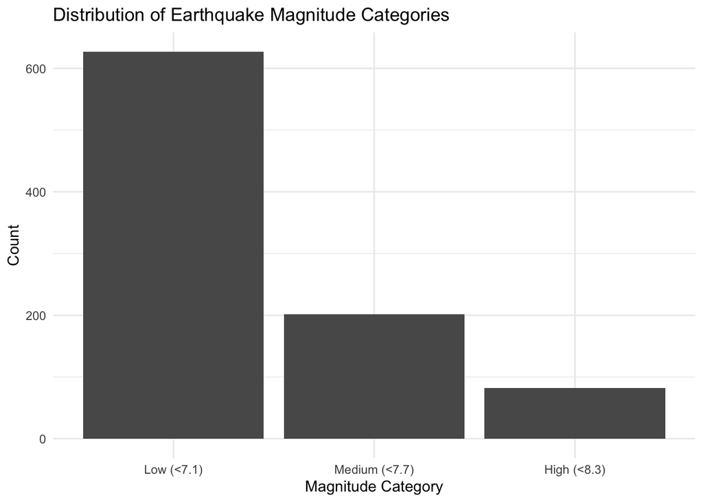

```r
#Fill magnitude_category
data_country$magnitude_category <- ifelse(
  is.na(data_country$magnitude), "NA",
  ifelse(data_country$magnitude < 7.1, "Low (<7.1)",
         ifelse(data_country$magnitude < 7.7, "Medium (<7.7)", "High (<8.3)"))
)

# The order of magnitude_category
data_country$magnitude_category <- factor(
  data_country$magnitude_category,
  levels = c("Low (<7.1)", "Medium (<7.7)", "High (<8.3)")
)

# Plot histogram
ggplot(data_country, aes(x = magnitude_category)) +
  geom_bar() +
  labs(title = "Distribution of Earthquake Magnitude Categories",
       x = "Magnitude Category",
       y = "Count") +
  theme_minimal()
```

The code creates a summary of the counts of earthquakes categorized by continent and magnitude_category. This table is allowing us to observe how the frequency of earthquake magnitudes is distributed across different continents.

```r
# Create a contingency table for the counts of earthquakes by category and country
contingency_table <- table(data_country$continent, data_country$magnitude_category)
print(contingency_table)
```

```
##
##                 Low (<7.1) Medium (<7.7) High (<8.3)
##   Africa                 5             0           0
##   Asia                 233            70          25
##   Europe                18             2           0
##   North America         27            19           5
##   Oceania              151            42          18
##   South America         75            24          11
##   Unknown              118            45          23
```

To assess whether there is a statistically significant association between the grouped continent and earthquake magnitude category, we apply the chi-squared test with the “simulate.p.value = TRUE” argument. This approach is used when the expected values in some cells are too small for the approximation of the test to be correct.

```r
# Group continents with fewer counts into "Other"
data_country$continent_grouped <- ifelse(
  data_country$continent %in% c("Africa", "Europe", "Oceania"),
  "Other",
  data_country$continent
)

contingency_table_grouped <- table(data_country$continent_grouped, data_country$magnitude_category)
print(contingency_table_grouped)
```

```
##
##                 Low (<7.1) Medium (<7.7) High (<8.3)
##   Asia                 233            70          25
##   North America         27            19           5
##   Other                174            44          18
##   South America         75            24          11
##   Unknown              118            45          23
```

```r
#Perform test
chisq_test_sim <- chisq.test(contingency_table_grouped, simulate.p.value = TRUE)
print(chisq_test_sim)
```

```
##
##  Pearson's Chi-squared test with simulated p-value (based on 2000
##  replicates)
##
## data:  contingency_table_grouped
## X-squared = 14.411, df = NA, p-value = 0.07096
```

Since the p-value is greater than the typical significance level of 0.05, we fail to reject the null hypothesis. There is not enough statistical evidence to say that magnitude (not) differs significantly across the continents.

# Using Heatmap

## Hypothesis: Proximity to Seismic Stations

Hypothesis:  
Earthquakes with smaller distances to the nearest seismic station (dmin) have more reliable intensity measurements, such as CDI (Community Internet Intensity Map) and MMI (Modified Mercalli Intensity).

Description:  
This hypothesis investigates whether the proximity of an earthquake to seismic stations influences the reliability of its intensity measurements. Earthquakes occurring closer to seismic stations are expected to provide more accurate and consistent data in terms of intensity (CDI and MMI) due to the higher density of monitoring equipment in the vicinity. By analyzing the correlation between dmin and intensity metrics, we aim to understand how distance from seismic stations may impact the quality of intensity reports.

Statistical Hypotheses:  
$H_0$: The mean distance to the nearest seismic station (dmin) does not differ significantly between earthquakes with reliable and less reliable intensity measurements (CDI, MMI).

$H_1$: The mean distance to the nearest seismic station (dmin) is smaller for earthquakes with reliable intensity measurements (CDI, MMI) than for those with less reliable intensity measurements.

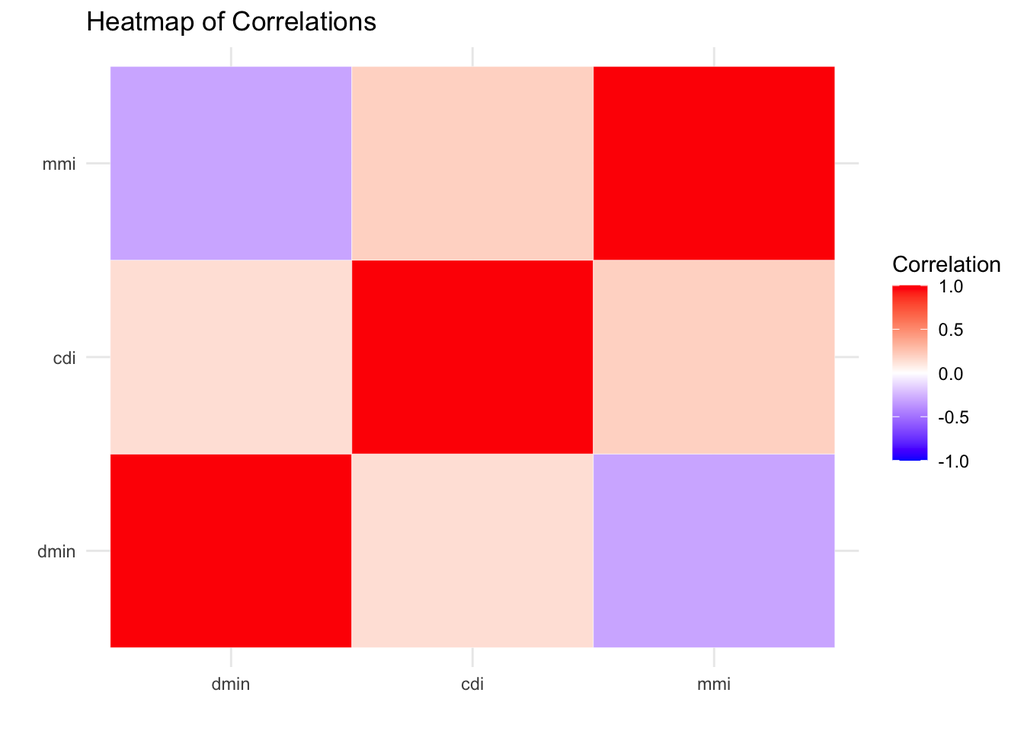

```r
library(ggplot2)
library(reshape2)

cor_matrix <- cor(data[, c("dmin", "cdi", "mmi")])

# Melt the correlation matrix for ggplot
cor_melt <- melt(cor_matrix)

# Plot heatmap
ggplot(cor_melt, aes(x = Var1, y = Var2, fill = value)) +
  geom_tile(color = "white") +
  scale_fill_gradient2(low = "blue", high = "red", mid = "white", midpoint = 0,
                       limit = c(-1, 1), name = "Correlation") +
  theme_minimal() +
  labs(title = "Heatmap of Correlations", x = "", y = "")
```

```r
# reliability based on cdi and mmi thresholds
data$reliability <- ifelse(data$cdi > 5 & data$mmi > 5, 1, 0)
table(data$reliability)
```

```
##
##   0   1
## 720 280
```

```r
# Subset data
reliable <- subset(data, reliability == 1)
less_reliable <- subset(data, reliability == 0)

# Perform t-test on dmin
t_test_result <- t.test(reliable$dmin, less_reliable$dmin)
print(t_test_result)
```

```
##
##  Welch Two Sample t-test
##
## data:  reliable$dmin and less_reliable$dmin
## t = 0.057067, df = 691.89, p-value = 0.9545
## alternative hypothesis: true difference in means is not equal to 0
## 95 percent confidence interval:
##  -0.2433072  0.2578743
## sample estimates:
## mean of x mean of y
##  1.130419  1.123135
```

The heatmap provides a visual representation of the correlations among “dmin`, "cdi`, and”mmi`. From the visualization, we observe a positive correlation between "cdi" and "mmi`, which is expected as both metrics measure earthquake intensity. However, the correlations between “dmin” and “cdi” is positive, and between “dmin” and “mmi” are negative.

The t-test is a statistical hypothesis test used to determine whether there is a significant difference between the means of one or two groups. It assumes that the data follows a normal distribution and is typically used when the sample size is small. There are three common types of t-tests:

Two-sample t-test compares the means of two independent groups. $t = \frac{\bar{x}_1 - \bar{x}_2}{\sqrt{\frac{s_1^2}{n_1} + \frac{s_2^2}{n_2}}},$ where $\bar{x}_1, \bar{x}_2$ are sample means, $s_1^2, s_2^2$ are variances, and $n_1, n_2$ are sample sizes.

The t-test is chosen in this case because it is specifically designed to compare the means of two groups to determine if the observed difference is statistically significant. In this context, we aim to test whether the mean distance to the nearest seismic station (dmin) differs between earthquakes with reliable versus less reliable intensity measurements (CDI, MMI).

The t-test results had a p-value of 0.9545, above the typical significance threshold of 0.05. This high p-value indicates a failure to reject the null hypothesis.

## Hypothesis: Relationship Between Magnitude and Impact

Hypothesis:  
Earthquakes with higher magnitudes are associated with greater significance and higher reported intensities, such as CDI and MMI.

Description:  
This hypothesis explores whether larger earthquakes, as measured by magnitude, tend to result in more significant impacts and higher intensity values in reports such as CDI and MMI. Earthquakes with higher magnitudes are generally expected to cause more severe shaking, which could lead to higher reported intensity values. By analyzing the relationship between the magnitude variable and the impact measures (sig, CDI, MMI), this hypothesis aims to assess how magnitude correlates with the severity and significance of earthquake impacts.

Statistical Hypotheses:  
$H_0$: There is no significant correlation between earthquake magnitude and impact measures (sig, CDI, MMI).  
$H_1$: There is a significant positive correlation between earthquake magnitude and impact measures (sig, CDI, MMI).

Test for this hypothesis is described below.

## Hypothesis: Depth and Intensity Relationship

Hypothesis:  
Shallower earthquakes (smaller depth) are associated with higher reported intensities (CDI) and instrumental intensities (MMI).

Description:  
This hypothesis examines whether the depth of an earthquake influences the intensity of its impact. Shallower earthquakes are generally expected to cause more noticeable ground shaking, leading to higher reported intensities, such as those found in the maximum reported intensity (CDI) and maximum estimated instrumental intensity (MMI). The hypothesis suggests that the depth of the earthquake has a negative relationship with intensity, meaning that as the depth decreases (the earthquake becomes shallower), the reported intensity (CDI and MMI) increases. By analyzing the relationship between earthquake depth and intensity, this hypothesis aims to understand how depth correlates with the perceived impact of an earthquake.

Statistical Hypotheses:  
$H_0$: There is no significant correlation between earthquake depth and intensity measures (CDI, MMI). $H_1$: There is a significant negative correlation between earthquake depth and intensity measures (CDI, MMI), with shallower earthquakes resulting in higher intensities.

Firstly, let’s check which values are interesting to test. To do this we can create a correlation matrix and check which values are related and in what way. The values in matrix mean: 1 - a strong positive correlation -1 - a strong negative correlation.

```r
library(dplyr)
```

```r
library(corrplot)
#Selecting columns we want to use
cor_data <- data %>% select(magnitude, depth, sig, cdi, mmi)

#Creating correlation matrix with Pearson  method
cor_matrix <- cor(cor_data, use = "complete.obs", method = "pearson")

print(cor_matrix)
```

```
##            magnitude       depth        sig        cdi        mmi
## magnitude 1.00000000  0.01708266  0.5123578  0.1631702  0.2822750
## depth     0.01708266  1.00000000 -0.0792629 -0.0513314 -0.5170020
## sig       0.51235783 -0.07926290  1.0000000  0.4799105  0.3981488
## cdi       0.16317023 -0.05133140  0.4799105  1.0000000  0.1974580
## mmi       0.28227495 -0.51700197  0.3981488  0.1974580  1.0000000
```

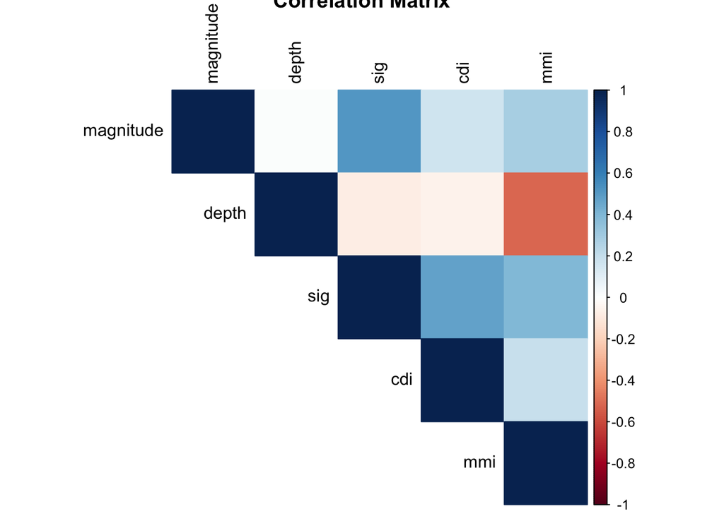

```r
#Plot the matrix
corrplot(cor_matrix, method = "color", type = "upper",
         title = "Correlation Matrix", tl.col = "black")
```

These are the rules when to use Pearson correlation:

1. Both variables are continuous.
2. The relationship between the variables is linear.
3. Data is approximately normally distributed.

But some of our data violates those rules, so we can try another test - Spearman (For monotonic relationships, non-linear but consistent increase/decrease, the data contains outliers and this method is less sensitive to them)

The Spearman correlation coefficient, $r_s$, is calculated using the ranked values of the variables $X$ and $Y$: $r_s = 1 - \frac{6\sum d_i^2}{n(n^2-1)}$, where $d_i = Rank(X_i) - Rank(Y_i)$, $n$ is the number of observations.

```r
# Creating correlation matrix with Spearman method
cor_matrix_spearman <- cor(cor_data, use = "complete.obs", method = "spearman")

print(cor_matrix_spearman)
```

```
##            magnitude       depth        sig         cdi        mmi
## magnitude 1.00000000  0.09569881 0.79226856  0.16852550  0.2638662
## depth     0.09569881  1.00000000 0.01623536 -0.06997162 -0.2842224
## sig       0.79226856  0.01623536 1.00000000  0.52047977  0.3826494
## cdi       0.16852550 -0.06997162 0.52047977  1.00000000  0.2074729
## mmi       0.26386622 -0.28422237 0.38264944  0.20747292  1.0000000
```

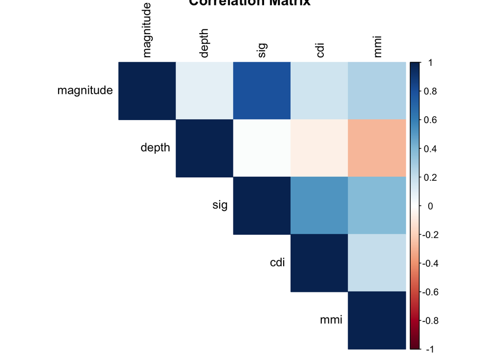

```r
#Plot the correlation matrix
corrplot(cor_matrix_spearman, method = "color", type = "upper",
         title = "Correlation Matrix", tl.col = "black")
```

```r
# Taking data we want to test
x <- data$magnitude
y <- data$sig

# Fit the data in the linear model
linear_model <- lm(y ~ x)

# Get some statistics about the model
summary(linear_model)
```

```
##
## Call:
## lm(formula = y ~ x)
##
## Residuals:
##     Min      1Q  Median      3Q     Max
## -336.17 -101.75  -57.87  -27.31 2112.13
##
## Coefficients:
##             Estimate Std. Error t value Pr(>|t|)
## (Intercept) -1601.40     130.21  -12.30   <2e-16 ***
## x             352.92      18.72   18.85   <2e-16 ***
## ---
## Signif. codes:  0 '***' 0.001 '**' 0.01 '*' 0.05 '.' 0.1 ' ' 1
##
## Residual standard error: 259.3 on 998 degrees of freedom
## Multiple R-squared:  0.2625, Adjusted R-squared:  0.2618
## F-statistic: 355.2 on 1 and 998 DF,  p-value: < 2.2e-16
```

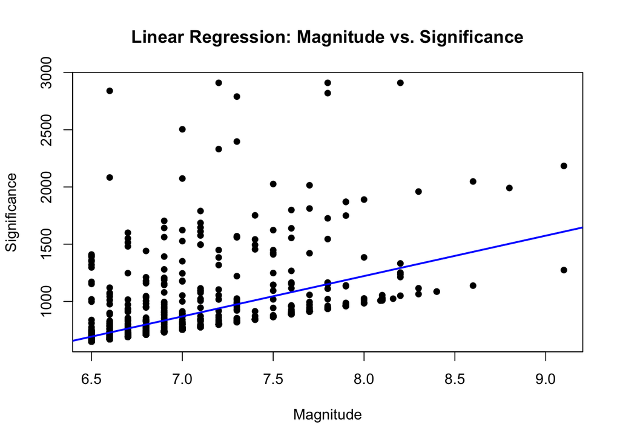

```r
# Plot the data
plot(x, y,
     pch = 16,
     main = "Linear Regression: Magnitude vs. Significance",
     xlab = "Magnitude",
     ylab = "Significance")

# Plot the regression line
abline(linear_model, col = "blue", lwd = 2)
```

Linear regression assumes a linear relationship between the independent variable x and the dependent variable y. In our case we have magnitude as x and significance as y. The relationship can be expressed as $y = \alpha + \beta x$, where $\alpha$ is an intercept and $\beta$ is a slope. We use a least squared method to estimate these parameters.

The formula for sum of squared residuals: $\sum (y_i - (\alpha + \beta x_i ))^2$

The regression process adjusts $\alpha$ and $\beta$ to minimize this SSR. The formulas for these estimates are:

$\beta = \frac{\sum(x_i−\bar{x})(y_i−\bar{y})}{\sum (x_i−\bar{x})^2}$

$\alpha = \bar{y}− \beta \bar{x}$

Conclusions:

The equation for linear regression becomes: $y = -1601.4 + 352.92x$ R-squared (which is the measure that indicates the proportion of the variance in the dependent variable y (significance) that is explained by the independent variable x (magnitude) in the model). It is calculated like this: $R^2 = 1 - \frac{SS_{residual}}{SS_{total}}$, where $SS_{residual} = \sum(y_i - \hat{y_i})^2$, $SS_{total} = sum(y_i - \bar{y_i})^2$. in our regression this statistic is much less than 0.7 indicating that our model does not provide a good fit.

```r
# Taking data we want to test
x <- data$depth
y <- data$mmi

# Fit the data in the linear model
linear_model <- lm(y ~ x)

# Get some statistics about the model
summary(linear_model)
```

```
##
## Call:
## lm(formula = y ~ x)
##
## Residuals:
##     Min      1Q  Median      3Q     Max
## -3.4102 -0.6889 -0.1814  0.7202  3.6130
##
## Coefficients:
##              Estimate Std. Error t value Pr(>|t|)
## (Intercept)  6.449864   0.044714  144.25   <2e-16 ***
## x           -0.005667   0.000297  -19.08   <2e-16 ***
## ---
## Signif. codes:  0 '***' 0.001 '**' 0.01 '*' 0.05 '.' 0.1 ' ' 1
##
## Residual standard error: 1.228 on 998 degrees of freedom
## Multiple R-squared:  0.2673, Adjusted R-squared:  0.2666
## F-statistic: 364.1 on 1 and 998 DF,  p-value: < 2.2e-16
```

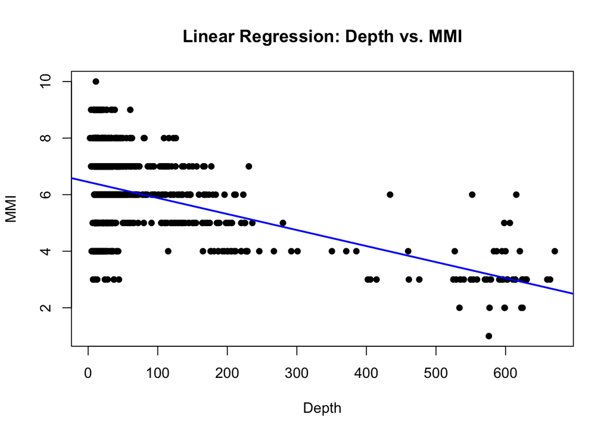

```r
# Plot the data
plot(x, y,
     pch = 16,
     main = "Linear Regression: Depth vs. MMI",
     xlab = "Depth",
     ylab = "MMI")

# Plot the regression line
abline(linear_model, col = "blue", lwd = 2)
```

For the second hypothesis we also tried to fit the data in the linear regression, but we observed, that the fit is not good enough, so we tried to fit the data in the polynomial regression, since we see, that the plot suggest a bit curved line.

```r
# Get the data needed for test
x <- data$depth
y <- data$mmi

#Fitting the data in the polynomial model
poly_model <- lm(y ~ poly(x, 3))

# Get some statistics on the regression
summary(poly_model)
```

```
##
## Call:
## lm(formula = y ~ poly(x, 3))
##
## Residuals:
##     Min      1Q  Median      3Q     Max
## -3.3478 -0.6385 -0.2142  0.6982  3.6580
##
## Coefficients:
##              Estimate Std. Error t value Pr(>|t|)
## (Intercept)   6.02700    0.03869 155.795  < 2e-16 ***
## poly(x, 3)1 -23.43263    1.22334 -19.155  < 2e-16 ***
## poly(x, 3)2   1.01327    1.22334   0.828  0.40771
## poly(x, 3)3   3.68435    1.22334   3.012  0.00266 **
## ---
## Signif. codes:  0 '***' 0.001 '**' 0.01 '*' 0.05 '.' 0.1 ' ' 1
##
## Residual standard error: 1.223 on 996 degrees of freedom
## Multiple R-squared:  0.2744, Adjusted R-squared:  0.2722
## F-statistic: 125.6 on 3 and 996 DF,  p-value: < 2.2e-16
```

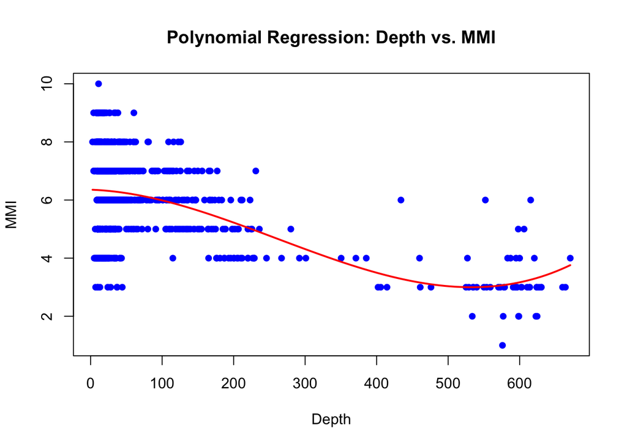

```r
# Plot the data
plot(x, y,
     pch = 16, col = "blue",
     main = "Polynomial Regression: Depth vs. MMI",
     xlab = "Depth", ylab = "MMI")

# Plot the regression
x_grid <- seq(min(x), max(x), length.out = 100)
y_pred <- predict(poly_model, newdata = data.frame(x = x_grid))

lines(x_grid, y_pred, col = "red", lwd = 2)
```

This approach is almost the same as the linear regression, but uses linear algebra theory to find the formulas for estimates of parameters.

The form of this regression is: $\hat{y_i} = \alpha + \beta_1x_i + \beta_2x_i^2 + \beta_3x_i^3$

To find the estimates for the parameters we also minimize the sum of squared residuals.

## Hypothesis: Tsunami and Oceanic Earthquakes

Hypothesis:  
Earthquakes in oceanic regions (tsunami = 1) tend to have larger magnitudes and are more significant than non-oceanic earthquakes.

Description:  
This hypothesis investigates whether earthquakes that occur in oceanic regions and are associated with tsunamis tend to be more powerful and significant compared to earthquakes in non-oceanic regions. Tsunami-generating earthquakes, which are often located in oceanic regions, may be larger in magnitude and have greater significance due to the potential for widespread damage and coastal effects. By comparing earthquake magnitudes and significance values (sig) between oceanic earthquakes (tsunami = 1) and non-oceanic earthquakes (tsunami = 0), this hypothesis aims to determine if oceanic earthquakes are statistically more intense and impactful.

Statistical Hypotheses:  
$H_0$: The mean magnitude and significance of earthquakes in oceanic regions are equal to those in non-oceanic regions. $H_1$: The mean magnitude and significance of earthquakes in oceanic regions are greater than those in non-oceanic regions.

```r
#Read the data
data <- read.csv("dataset/earthquake_1995-2023.csv")

# Select the data with and without tsunami
oceanic <- data$magnitude[data$tsunami == 1]
non_oceanic <- data$magnitude[data$tsunami == 0]

# Testing the data on normality
print(shapiro.test(oceanic))
```

```
##
##  Shapiro-Wilk normality test
##
## data:  oceanic
## W = 0.87269, p-value = 9.759e-16
```

```r
print(shapiro.test(non_oceanic))
```

```
##
##  Shapiro-Wilk normality test
##
## data:  non_oceanic
## W = 0.85104, p-value < 2.2e-16
```

Since our data does not follow a normal distribution, we try to transform the data (in different ways), but it did not change the distribution.

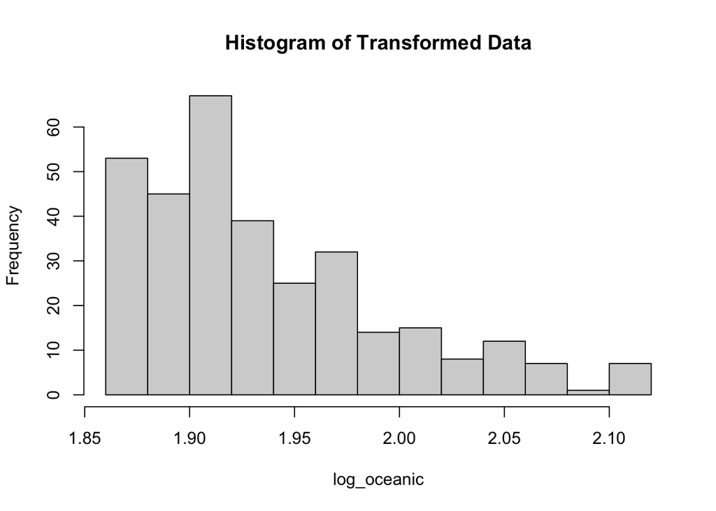

```r
#transforming the data
log_oceanic <- log(oceanic)
hist(log_oceanic, main = "Histogram of Transformed Data")
```

```r
#Testing the data on normality
shapiro_result <- shapiro.test(log_oceanic)
print(shapiro_result)
```

```
##
##  Shapiro-Wilk normality test
##
## data:  log_oceanic
## W = 0.88767, p-value = 1.01e-14
```

After trying to make some transformation to make our distribution normal we decided to try another test:

Mann-Whitney U Test

Why do we choose this test?

1. Does not require data to follow a normal distribution.
2. Compares the median (not the mean) between the two groups.

Restrictions:

The two samples are independent. The measurement scale is ordinal, interval, or ratio. The shapes of the distributions in the two groups are assumed to be similar (but not identical).

Null Hypothesis ($H_0$): The distributions of the two groups are the same (oceanic and non-oceanic earthquakes). Alternative Hypothesis ($H_1$): One group tends to have larger values than the other (e.g., oceanic earthquakes have larger magnitudes)

The Mann-Whitney U test ranks all data points from both groups combined, then compares the ranks between groups. The U-statistic measures how much one group’s ranks differ from the other’s.

How to conduct this type of a test?

1. We have two independent samples of different sizes ($n_1$ and $n_2$). Then we combine these two samples in one set of values of size $n = n_1 + n_2$.
2. Next, we rank the combined data in ascending order, assigning the average rank to tied values. Then, we calculate $R_i$, which are the sum of ranks: $R_i = \text{Sum of ranks for Group i}$. In our case Group 1 is the oceanic earthquakes and 2 - non-oceanic.
3. Next, we use these ranks to compute the test statistics ($U_1$ and $U_2$). For this we use formulas: $U_1 = R_1 - \frac{n_1(n_1 + 1))}{2}$ and $U_2 = R_2 - \frac{n_1(n_1 + 1))}{2}$ The test statistic $U = min(U_1, U_2)$.
4. Since our samples have large sizes, we approximate the U-statistic by a normal distribution: $Z = \frac{U - \mu_U}{\sigma_U}$, where $\mu_U = \frac{n_1n_2}{2}$ and $\sigma_U = \sqrt{\frac{n_1n_2(n_1 + n_2 + 1)}{12}}$
5. Now, we can find the p-value for this test: $p = P(Z \lt U)$, where $Z \sim N(0, 1)$. If our p-value is less then the significance level $\alpha$, then we reject the null hypothesis.

```r
#Test of the first hypothesis
test_result <- wilcox.test(oceanic, non_oceanic, alternative = "greater")

print(test_result)
```

```
##
##  Wilcoxon rank sum test with continuity correction
##
## data:  oceanic and non_oceanic
## W = 111916, p-value = 0.3002
## alternative hypothesis: true location shift is greater than 0
```

Since p-value is greater than 0.05, we DO NOT reject $H_0$ (we can not reject, that the distribution of magnitude of oceanic and non-oceanic earthquakes does not differ).

```r
#Test of the second hypothesis
oceanic_sig <- data$sig[data$tsunami == 1]
non_oceanic_sig <- data$sig[data$tsunami == 0]
test_result <- wilcox.test(oceanic_sig, non_oceanic_sig, alternative = "greater")

print(test_result)
```

```
##
##  Wilcoxon rank sum test with continuity correction
##
## data:  oceanic_sig and non_oceanic_sig
## W = 116004, p-value = 0.0698
## alternative hypothesis: true location shift is greater than 0
```

# Predicting Earthquake Alert Levels Using a Decision Tree Classifier

Objective:  
To predict the alert level of earthquakes (e.g., green, yellow, orange, red) based on earthquake features such as magnitude, depth, significance (sig), tsunami occurrence, and maximum instrumental intensity (mmi).

Description:  
We’re building a decision tree classifier to model the relationship between earthquake characteristics and their alert levels. An alert level is a categorical label that shows how serious and dangerous an earthquake is. We’ll use features like magnitude, depth, significance (sig), tsunami occurrence (binary: 1 if a tsunami is generated, 0 otherwise), and maximum instrumental intensity (mmi) to predict the alert level.

- The significance ($sig$) is calculated using columns like magnitude, cdi, tsunami, latitude/longitude, and location, combining earthquake size, reported intensity, proximity to populated areas, and tsunami generation to quantify overall impact.
- The maximum instrumental intensity ($mmi$) is calculated using magnitude, depth, dmin, and nst, representing the strongest ground shaking recorded, adjusted for earthquake size, depth, and station coverage.

We’re choosing a decision tree classifier because it’s easy to understand and can handle complex relationships between features. The model will create a tree-like structure where conditions on the features split the data into smaller groups, and then it’ll assign an alert level based on these splits. This approach will give us clear insights into how different factors affect the alert level, and it’ll also make it easy to see how the model makes decisions.

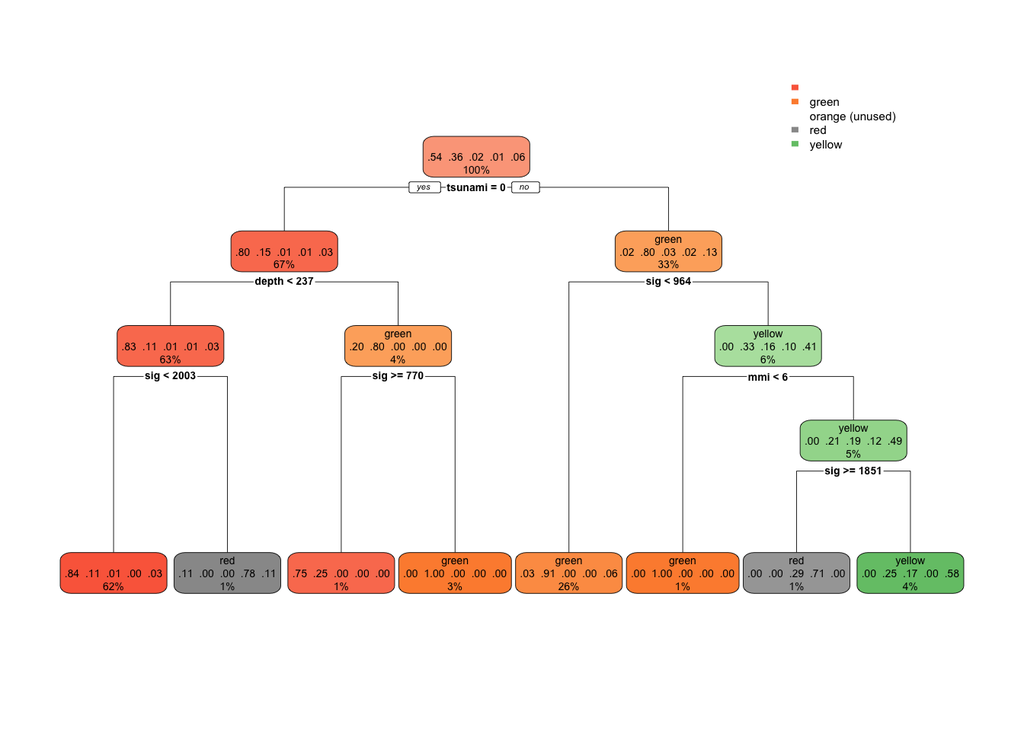

```r
library(rpart)
library(rpart.plot)
data$alert <- as.factor(data$alert)

set.seed(123)
sample_index <- sample(1:nrow(data), 0.8 * nrow(data))
train_data <- data[sample_index, ]
test_data <- data[-sample_index, ]

# Build the decision tree model
tree_model <- rpart(alert ~ magnitude + depth + sig + tsunami + mmi,
                    data = train_data,
                    method = "class")

# Visualize the decision tree
rpart.plot(tree_model)
```

```r
# Make predictions
predictions <- predict(tree_model, test_data, type = "class")

# Confusion matrix and accuracy
confusion_matrix <- table(test_data$alert, predictions)
print(confusion_matrix)
```

```
##         predictions
##              green orange red yellow
##          118     0      0   0      0
##   green   11    51      0   0      0
##   orange   5     0      0   0      4
##   red      0     0      0   1      0
##   yellow   2     5      0   0      3
```

```r
accuracy <- sum(diag(confusion_matrix)) / sum(confusion_matrix)
print(paste("Accuracy:", round(accuracy * 100, 2), "%"))
```

```
## [1] "Accuracy: 86.5 %"
```

## Explanation

The decision tree classifier achieved an accuracy of 86.5 % in predicting earthquake alert levels using features like magnitude, depth, significance (sig), tsunami occurrence, and maximum estimated instrumental intensity (mmi) and shows how those features influence alert level predictions. While the model performs well, some misclassifications, particularly in “orange” and “yellow” levels, highlight areas for improvement.

## How Decision Tree Classifiers Work:

A decision tree classifier is an algorithm that predicts classes by splitting data into branches based on feature thresholds and is used to make decisions or predictions. Each internal node corresponds to a test on an attribute, each branch corresponds to the result of the test, and each leaf node corresponds to a class label or a continuous value. It selects the best attribute using a metric like **Gini impurity**, **entropy**, or **information gain**, the best attribute to split the data is selected. Then it splits the given dataset into subsets based on the selected attribute. We repeat the process recursively for each subset, creating a new internal node or leaf node until a stopping criterion is met (it can be that all instances in a node belong to the same class or a predefined depth is reached).

**Gini** measures the likelihood of an incorrect classification of a new instance if it was randomly classified according to the distribution of classes in the dataset. It is calculated as:

$1 - \sum_{i=1}^{n} (p_i)^2$,

where $p_i$ is the probability of an instance being classified into a particular class.

**Entropy** measures the amount of uncertainty or impurity in the dataset. It is calculated as:

$- \sum_{i=1}^{n} p_i \log_2(p_i)$,

where $p_i$ is the probability of an instance being classified into a particular class.

**Information gain** measures the reduction in entropy or Gini impurity after a dataset is split on an attribute. It is calculated as:

$\text{Entropy}{\text{parent}} - \sum{i=1}^{n} \frac{|D_i|}{|D|} \cdot \text{Entropy}(D_i)$,

where $D_i$ is the subset of $D$ after splitting by an attribute.